# A3: Incarceration - Mohamed Aden

### Introduction

A significant issue heard of constantly is the population proportion of minorities in prison populations, specifically African Americans. I was initially going to only examine the first CSV (prison data set for county/state), but I’m also interested in the jail’s data set and what it can tell us. Considering the jails are different than prison in regards of process (jail is where you wait prior to court hearings while prison is where those convicted of crimes go), looking at the two data sets and comparing the population proportions within them I’m interested to see what we can tell. The variable we will constantly be looking at is total jail population and prison populations because this is what will allow us to maintain a broad perspective of the incarceration situation, alongside the Black populations as these two in conjunction with each other tell us the true story (or rather, contributes to our existing knowledge of it). We are looking at black population proportions in comparison to total comparison as well in both jails and prisons at the county and state level with the years examined being 2000-2013 to accommodate for any discrepancies we may see between the prison and jail data groups by using only DCRP (individual) and NCRP (facilital-level) data. We will often look at the most recent year to get a sense of the most recent update on the situation using the data available and still working within self-given constraints.

### The Dataset

Who collected the data?

Vera Institute of Justice had a project called Incarceration Trends which was intended to educate the public about mass incarcerations and the details in them. They used data collected by the U.S. Department of State Justice Statistics (abbreviated as BJS), which consists of data collected by the National Corrections Reporting Program, Deaths in Custody Reporting Program, Annual Survey of Jails, and the Census of Jails.

How was the data collected or generated?

Through Census’, Surveys, CDC Data sets, US dept. of Agriculture’s Commuting Zones and Labor Market Areas.

Why was the data collected?

For several purposes, all dependent on who was collecting the data and their intentions. There are clear intentions such as providing better insights to the public about incarceration statistics, that warranted collecting this data.

How many observations (rows) are in your data?

*Prison:* 153,811 rows

*Jail:* 153,811 rows

How many features (columns) are in the data?

*Prison:* 153,811 rows

*Jail:* 153,811 rows

What, if any, ethical questions or questions of power do you need to consider when working with this data?

Who was in charge of the data and their intentions. Intentions are important to consider because if there’s a positive intention for with the betterment of society at mind such as educating the public on a matter, and then there’s also the same dataset but curated with ill intentions in mind (such as misinformation) then it’s obvious that there may be more to consider such as biases and other factors that may be influencing the clarity of the data at hand.

What are possible limitations or problems with this data? (at least 200 words)

There are some discrepancies in the data that could definitely harm the credibility of the analysis and the results. Firstly, there’s a lot of replacement of data to fill voids that exist there but this also runs the risk of not truly representing the data as accurately as possible if there’s a miscalculation (or this replacement of data is not as accurate as it truly is to be) then this data neglects it (makes note of it still) and this is dangerous as this may create the misconception that this data can be trusted completely when in reality, there are many factors that may have affected it’s credibility. For the prison data, the NCRP data includes sentences of less than one year except for some states from different year ranges. This is problematic for more reasons than one, but the most glaring issue being special cases. If not careful to extract these states beforehand or even not acknowledging the special cases, then down the road, there’s a good chance whatever representation of data attempted will not be as accurate as compared to if these states were not extracted. By ackloweding these discrepancies and acting accordingly to still represent the data in a “fair” way, it allows for a smoother and more trustable end result of whatever anaylsis is being done.

### Trends Over Time Chart

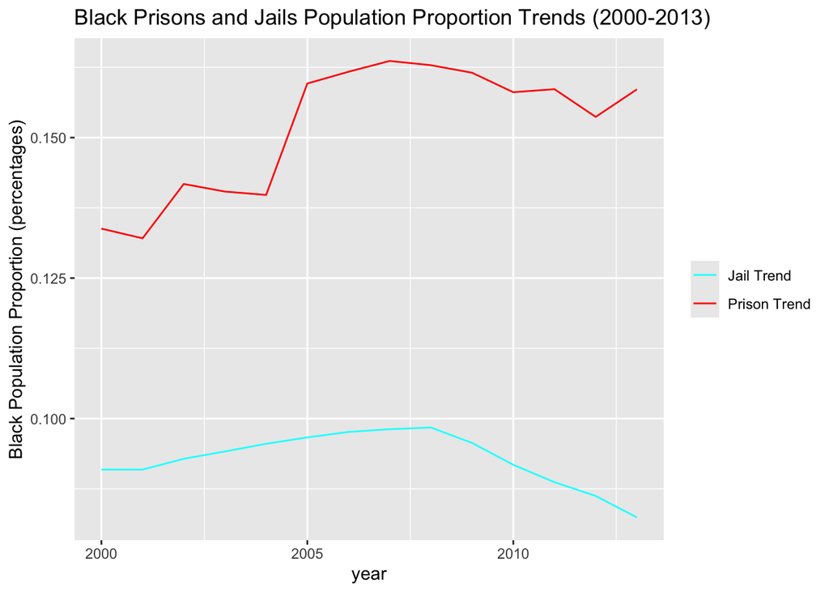

```r
library(ggplot2)
source("summary.R")
ggplot() +
  geom_line(data = black_prison_proportion_trend, aes(x = year, y = black_prison_proportion, color = "Prison Trend")) +
  geom_line(data = black_jail_proportion_trend, aes(x = year, y = black_jail_proportion, color = "Jail Trend")) +
  labs(title = "Black Prisons and Jails Population Proportion Trends (2000-2013)",
       x = "year",
       y = "Black Population Proportion (percentages)") +
  scale_color_manual(values = c("Prison Trend" = "red", "Jail Trend" = "cyan")) +
  theme(legend.title = element_blank())
```

*This chart is helpful in showing the trends over time in the black populations in prisons and jails, and a pattern seen is jail population proportions for black individuals decreasing while prison population proportions have climbed a decent amount suggesting the possibly of black people being sentenced to prison at a increasing rate in proportion to the total count in prisons (across all counties)*

### Variable Comparison Chart

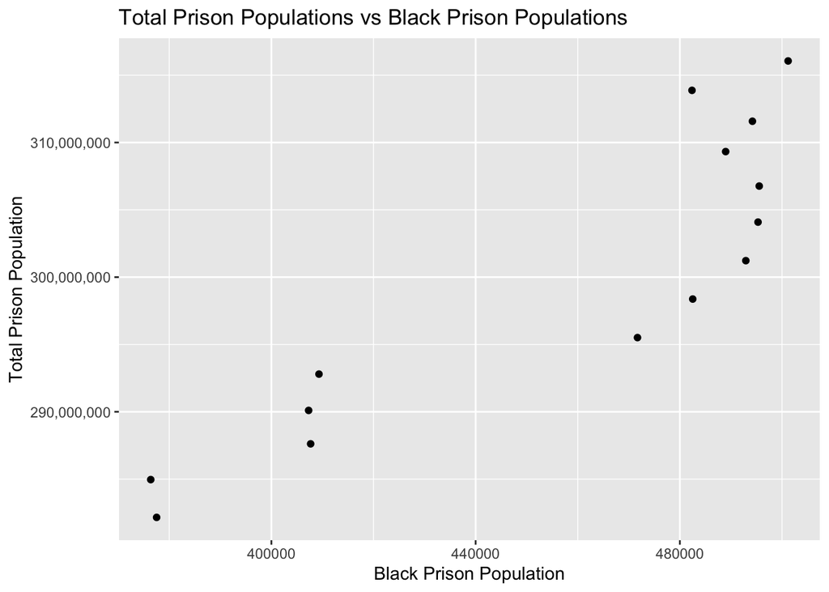

```r
library(ggplot2)
ggplot(black_prison_proportion_trend, aes(x = total_black_prison_pop, y = total_prison_pop)) +
  geom_point() +
  labs(title = "Total Prison Populations vs Black Prison Populations",
       x = "Black Prison Population",
       y = "Total Prison Population") +
  scale_y_continuous(labels = scales::comma)
```

### Map

[figure not shown]

```r
library(ggplot2)
library(dplyr)
library(maps)

# Loading map data
us_state_map <- map_data("state")

# Creating table
state_names <- data.frame(
  state = tolower(state.abb),
  full_name = tolower(state.name)
)

# Joining data
black_prison_proportion_by_state <- black_prison_proportion_by_state %>%
  left_join(state_names, by = "state")

# Merging map data
states_proportions_merge <- us_state_map %>%
  left_join(black_prison_proportion_by_state, by = c("region" = "full_name"))

ggplot(data = states_proportions_merge) +
  geom_polygon(aes(x = long, y = lat, group = group, fill = black_prison_proportion), color = "white") +
  labs(title = "Black Prison Population Proportions (by state)",
       fill = "Proportion (%)") +
  coord_map() +
  theme_minimal()
```